# FinanceAnalyst

### Distribution of Returns Analysis:

- Most stocks show a roughly normal distribution of daily returns, indicating stable trading behavior
- NVDA and TSLA exhibit wider distributions → higher volatility and risk
- MSFT and AAPL show tighter distributions → more stable returns
- Extreme tails (outliers) indicate sudden market movements or news-driven shocks

Conclusion: High-growth stocks tend to have higher return dispersion, while mature companies provide more consistent returns with lower volatility.

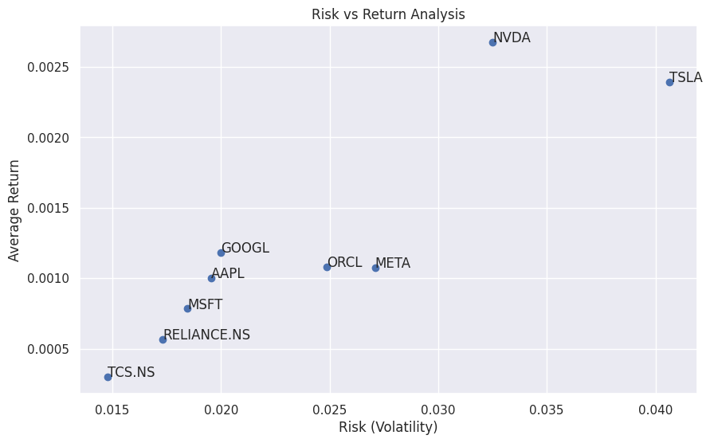

```python
import matplotlib.pyplot as plt

mean_returns = returns.mean()
risk = returns.std()

plt.figure(figsize=(10,6))
plt.scatter(risk, mean_returns)

for i in tickers:
    plt.text(risk[i], mean_returns[i], i)

plt.xlabel("Risk (Volatility)")
plt.ylabel("Average Return")
plt.title("Risk vs Return Analysis")
plt.show()
```

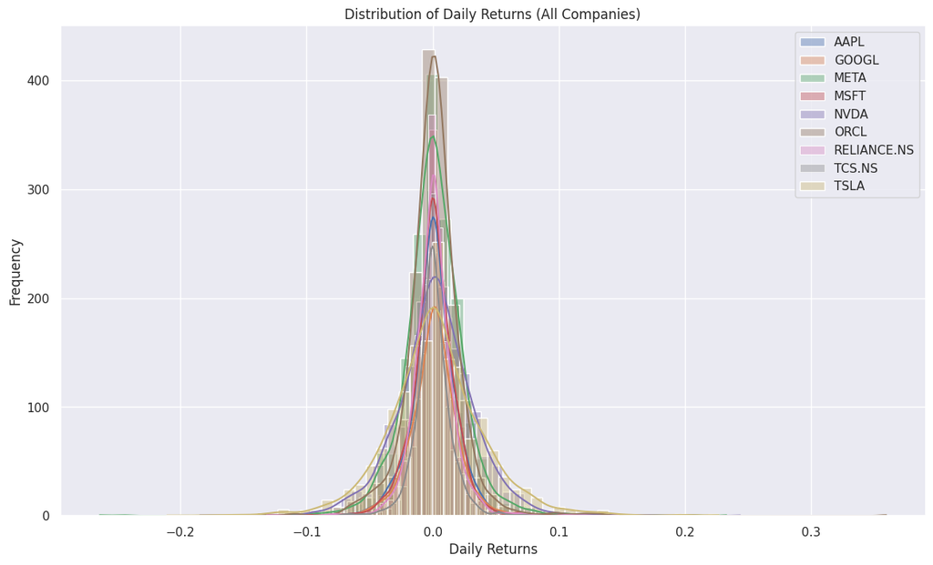

```python
plt.figure(figsize=(14,8))

for ticker in returns.columns:
    sns.histplot(returns[ticker], bins=50, kde=True, label=ticker, alpha=0.4)

plt.legend()
plt.title("Distribution of Daily Returns (All Companies)")
plt.xlabel("Daily Returns")
plt.ylabel("Frequency")
plt.show()
```

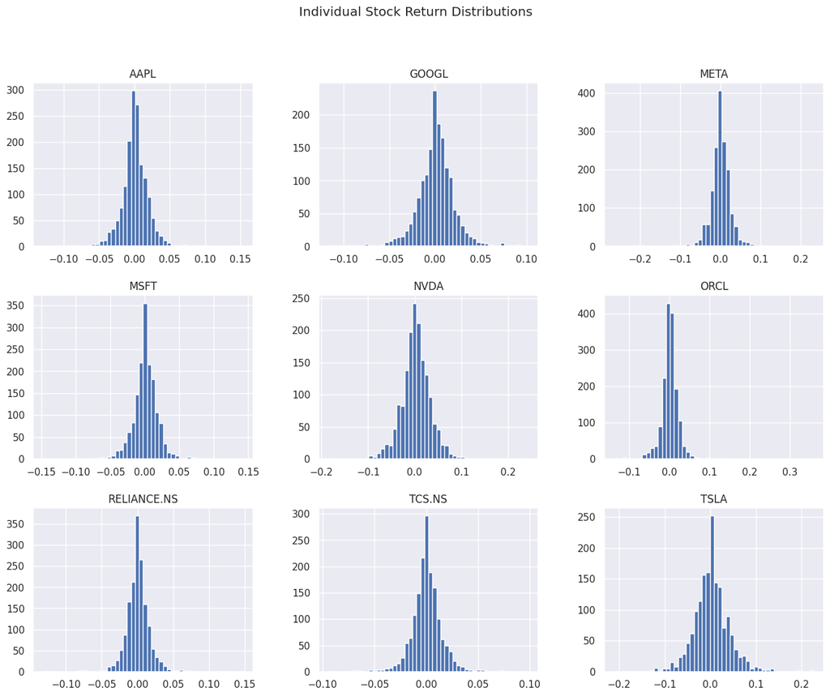

```python
returns.hist(bins=50, figsize=(16,12))
plt.suptitle("Individual Stock Return Distributions")
plt.show()
```